# TIPNet report (1992 - 2021)

Italian Pediatric Intensive Care Units Network (**TIPNet**) in collaboration with: * Italian Society of Pediatric and Neonatal Anesthesia and Intensive Care (**SARNePI**) * Unit of Biostatistics, Epidemiology and Public Health (**UBEP**) — University of Padova.

**Last report update**: 2021-11-02 — **Last data update**: 2021-10-28

# Colophon

**Network coordinator**: Andrea Wolfler, MD ([Department of Anesthesia and Intensive Care Unit](https://www.asst-fbf-sacco.it/reparti-e-servizi/info/anestesia-e-rianimazione-pediatrica) – [Children’s Hospital Vittore Buzzi](https://www.asst-fbf-sacco.it/reparti-e-servizi/ricerca-reparto-presidio/buzzi)) — Milan

**In collaboration with**: Unit of Biostatistics, Epidemiology and Public Helath ([UBEP](https://ubesp.jimdo.com/)), [Department of Cardiac, Toracic, Vascular sciences and Public Health](https://www.dctv.unipd.it/) – [University of Padova](https://www.unipd.it/) — Interuniversity Consortium

- Dario Gregori (head of UBEP)
- Corrado Lanera (Laboratory of Artificial Intelligence for Medical Sciences)
- Giulia Lorenzoni, Honoria Ocagli (Laboratory of Clinical Epidemiology)
- Rosanna Comoretto (Laboratory for Health Service Research)
- Matteo Martinato, Laura Nasato (Service for Clinical Trials and Biometrics)

**Business intelligence analyst**: Roberta Amato

**IT Project Managers**: Dario Gregori, Corrado Lanera

**With the contribution of**:

- F. Racca, J Gualino - Alessandria
- F. Ferrero, R Osello, R Gilodi - Novara
- I Salvo, E. Zoia, A. Mandelli - Milano
- E Calderini, C. Montani, E. Prandi - Milano
- P. Biban, P Santuz - Verona
- A. Pettenazzo, A Amigoni - Padova
- S. Furlan, F Savron - Trieste
- F Caramelli, C. Mondardini, E. Iannella - Bologna
- C Cecchetti, D Perrotta - Roma
- S Picardo, E Rossetti - Roma
- M Corbari - Roma
- G. Conti, M Piastra, O. Genovese - Roma
- R Testa, A Dolcini, L. D’Amato - Napoli
- G Coffaro, A. M. Guddo, A. M. Giglio - Palermo
- E Gitto - Messina
- G Stancanelli - Catania

**TIPNet study group** - participating center:

- Department of Anesthesia and Intensive Care, Children’s Hospital Sant’Antonio e Biagio e Cesare Arrigo, Alessandria:
- Department of Pediatrics, Ospedale Maggiore della Carità, Novara:
- Department of Anesthesia and Intensive Care, Children’s Hospital V Buzzi, Milan:
- Department of Anesthesia and Intensive Care, Fondazione IRCCS Ca Granda, Ospedale Maggiore Policlinico, Milan:
- Department of Pediatric Anesthesia and Intensive Care, Spedali Civili, Brescia
- Department of Neonatal and Paediatric Intensive Care, Azienda Ospedaliera Universitaria Integrata, Verona
- Department of Woman’s and Child’s Health, Pediatric ICU, University Hospital, Padova
- Department of Anesthesia and Intensive Care, Institute for Maternal and Child health, IRCCS Burlo Garofolo, Trieste
- Department of Pediatric Anesthesia and Intensive Care, Ospedale Sant’Orsola Malpighi, Bologna
- Department of Anesthesia and Intensive Care, Children’s Hospital Meyer, Firenze
- Department of Anesthesia and Intensive Care, Children’s Hospital Bambino Gesù, Rome DEA, ARCO, Palidoro
- Anesthesia and Intensive Care Department, Pediatric ICU, Policlinico Universitario A.Gemelli, Università Cattolica del Sacro Cuore, Rome
- Department of Anesthesia and Intensive Care, Children’s Hospital Santobono-Pausillipon, Napoli
- Department of Anesthesia and Intensive Care, Children’s Hospital G Di Cristina, Palermo
- Department of Anesthesia and Intensive Care Ospedale Garibaldi – Nesima, Catania
- Department of Pediatrics Ospedale Policlinico –Universitario G Martino, Messina

# 1 Quality

## Overview

A record is considered *completed* when it has at least the sheets **anagrafica**, **accettazione**, **pim**, **dimissione** marked as completed.

## 1.1 Complete records

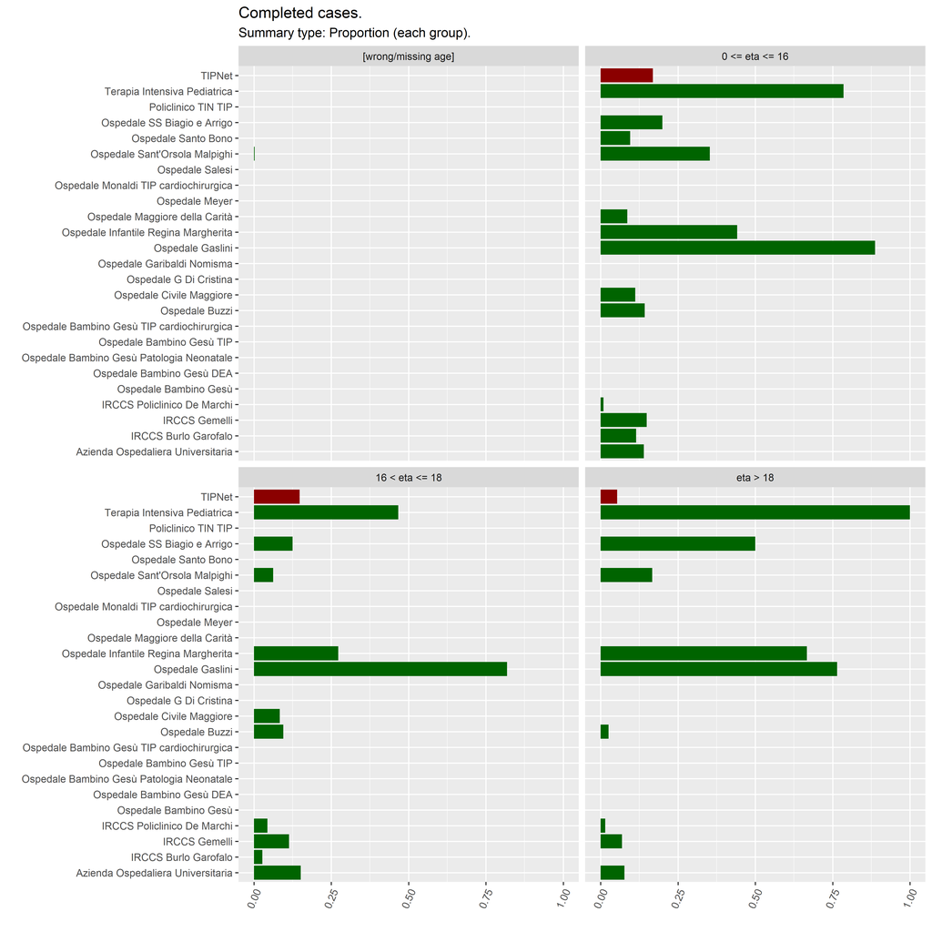

## 1.2 Hospitalized

Records are considered related to an “hospitalized” patient if the field **reparto** is not missing in the sheet **dimissione**.

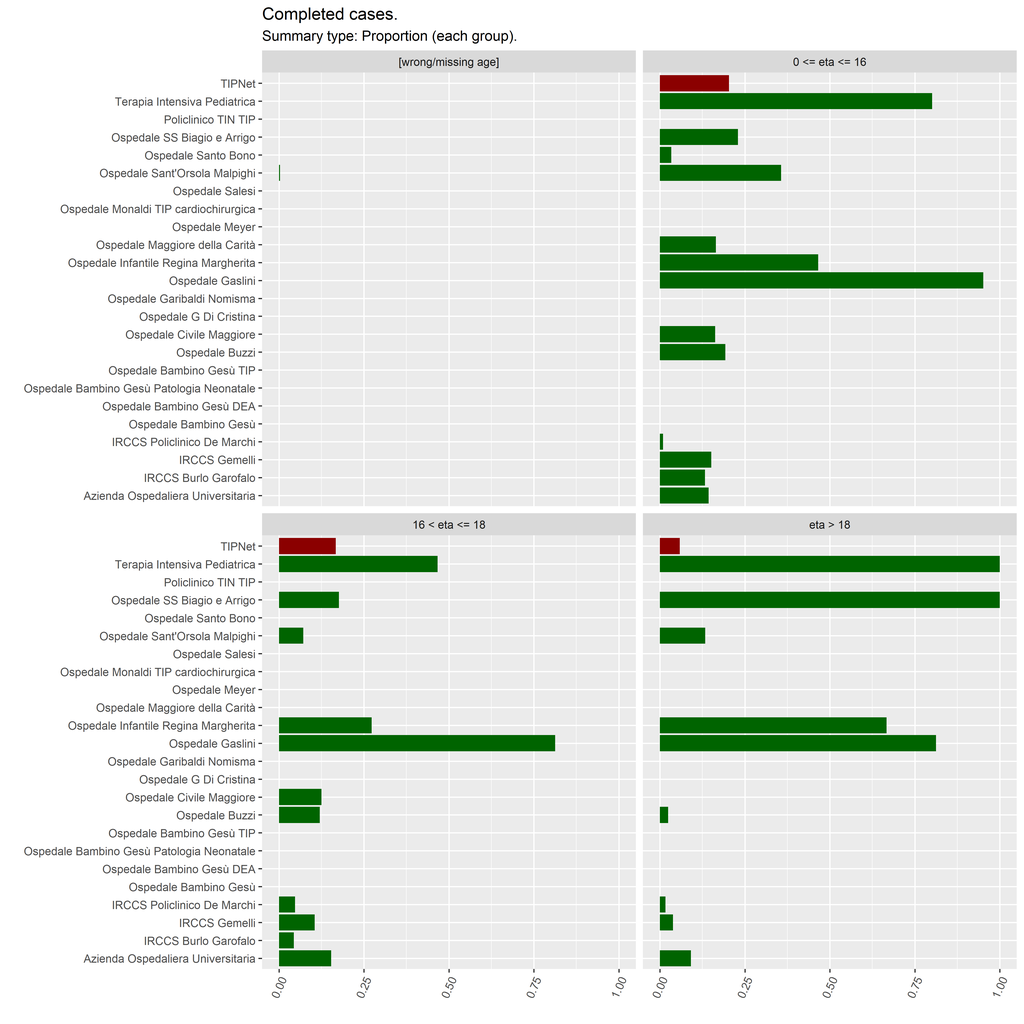

## 1.3 Data errors

Two types of errors are considered at the moment:

1. Missing data.
2. Outlier values out of reasonable range, i.e., which have a distance from the median that is farther than 1.5 times the inter quartile range.

### 1.3.1 Missing values

Overall, there are 647 variables with some missing data (out of 649) for a total number of 22425518 missing entries in the whole dataset (88.43% of missingness).

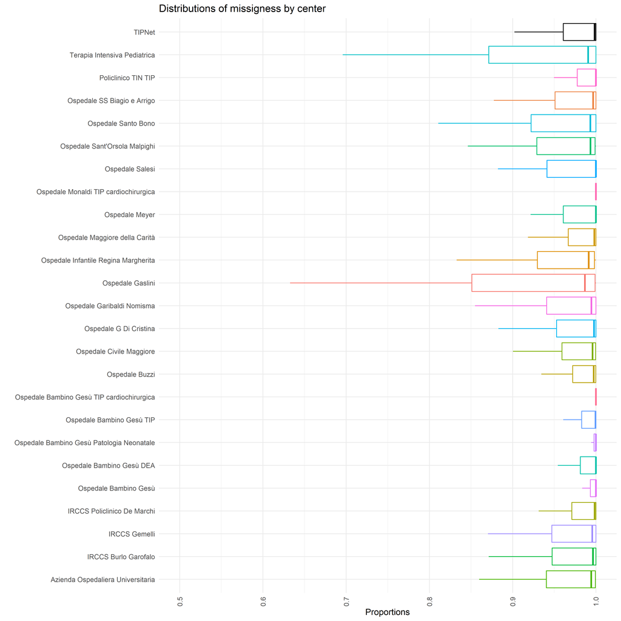

|  | center | field | missing (%) |
| --- | --- | --- | --- |

### 1.3.2 Possible errors into the data

For numerical variables, outliers are considered possible errors, i.e. values farther than 1.5 times the inter quartile range from the median.

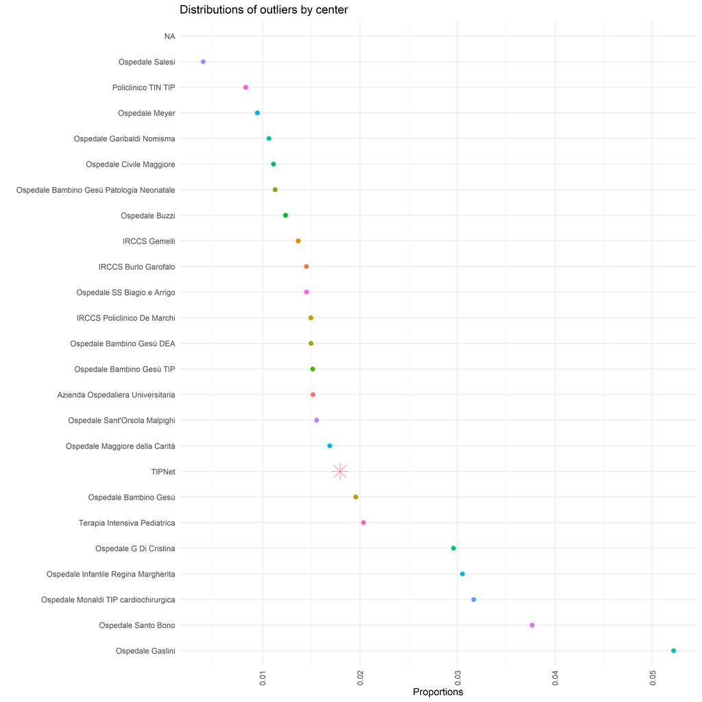

|  | codpat | redcap_repeat_instance | variable | value |
| --- | --- | --- | --- | --- |

# 2 Descriptive and Demographic

## Overview

In Italy there are 23 medical surgical (M/S) Pediatric Intensive Care Units (PICUs):

- 11 in the north
- 8 in the center
- 4 in the south

of the country.

Data reported here analyze patients admitted in PICUs from 1992 to 2021.

Only children 0 – 16 years old who have a severity score on admission which allow to estimate a Standardized Mortality Ratio (SMR) were considered.

Exclusion criteria were “preterm or > 16 years old,” or not completed data entry

## 2.2 Admissions

### 2.2.1 Gender

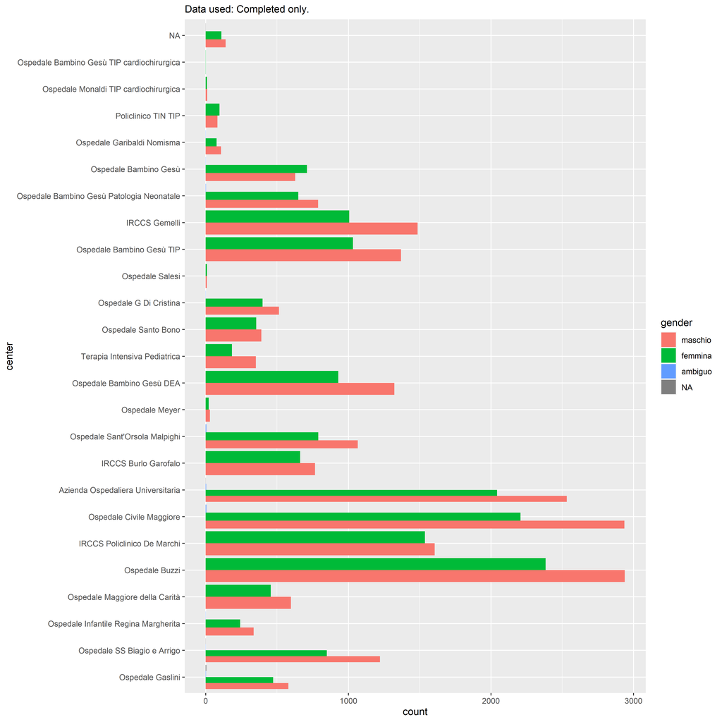

## 2.3 Demographics

# 3 Type of Admission and Origin

## Overview

The system allow to distinguish the first from subsequent admissions in the same unit. Admission was coded as mode, type, origin

**Mode**:

- planned (defined as admission that might be postponed for 24 hours)
- unplanned

**Type**:

- medical
- surgical
- trauma

**Origin**:

- ward
- emergency room
- operating room
- other hospital
- home
- other origin

> number of admission for the same patient beside the first

## 3.1 Planned and Unplunned

### 3.1.1 Overview

### 3.1.2 Re-admissions

### 3.1.3 Distribution by units

### 3.1.4 Distribution by origin

## 3.2 Origin and type

### 3.2.1 Overview

### 3.2.2 Other hospital

### 3.2.3 Distribution by units

### 3.2.4 Type

### 3.2.5 Type of surgery

## 3.3 Reasons

### 3.3.1 Post-operative PICUs admissions

### 3.3.2 Medical PICUs admissions

### 3.3.3 Trauma

### 3.3.4 brain trauma

### 3.3.5 PICUs admission after injuries

# 4 Chronic Complex Conditions (CCC) on Admissions

## Overview

Chronic complex condition definition was taken by the paper of Feudtner C et al: “Pediatric Deaths Attributable to Complex Chronic Conditions: A Population-Based Study of Washington State, 1980-1997” published in Pediatrics in 2000 (106:205-209) and was defined as “any medical condition that can be reasonably expected to last at least 12 months, unless death intervenes, and to involve either one or more different organ systems.” CCC were divided within 10 categories (defined macrodiagnosis): neurologic, neuromuscular, cardiologic, oncoematologic, respiratory, syndromic, renal, metabolic, malformation, other. Moreover, the system allows to record the specific chronic disease

## 4.1 Comorbidity on admission

## 4.2 Macro-diagnosis

## 4.3 CCC

### 4.3.1 Rate by center

### 4.3.2 Type

### 4.3.3 Age

# 5 Severity on admission and outcome

## Overview

The registry adopted, since the beginning, the Pediatric Index of Mortality (PIM) score. The PIM2 variables are recorded and the risk of death is automatically calculated by the system. In 2013, after a revision of the coefficient of the variables, the new PIM3 score was published. We updated the PIM page with the new formula and since 2014 we calculate both the 2 and 3 version. Moreover, retrospectically, we collected all the new variables and through the new coefficients we derived the PIM3 score for all the patient in the registry.

The Standardized Mortality Ratio (SMR) was estimated as the ratio between observed deaths/expected deaths. Expected deaths were derived as the sum of all the PIM scores for each category considered.

## 5.1 PIM 2 and 3

### 5.1.1 Severity

### 5.1.2 Age

### 5.1.3 Year

### 5.1.4 Type

### 5.1.5 Unit

## 5.2 Mortality and Standardized Mortality Ratio (SMR)

### 5.2.1 PIM 2 and 3

### 5.2.2 Age

### 5.2.3 Year

### 5.2.4 Type

### 5.2.5 Unit

## 5.3 Predictive moratality models

### 5.3.1 PIM 2 and 3

# 6 Severity on admission and outcome

## Overview

The registry adopted, since the beginning, the Pediatric Index of Mortality (PIM) score. The PIM2 variables are recorded and the risk of death is automatically calculated by the system. In 2013, after a revision of the coefficient of the variables, the new PIM3 score was published. We updated the PIM page with the new formula and since 2014 we calculate both the 2 and 3 version. Moreover, retrospectically, we collected all the new variables and through the new coefficients we derived the PIM3 score for all the patient in the registry.

The Standardized Mortality Ratio (SMR) was estimated as the ratio between observed deaths/expected deaths. Expected deaths were derived as the sum of all the PIM scores for each category considered.

## 6.1 PIM 2 and 3

### 6.1.1 Severity

### 6.1.2 Age

### 6.1.3 Year

### 6.1.4 Type

### 6.1.5 Unit

## 6.2 Mortality and Standardized Mortality Ratio (SMR)

### 6.2.1 PIM 2 and 3

### 6.2.2 Age

### 6.2.3 Year

### 6.2.4 Type

### 6.2.5 Unit

## 6.3 Predictive moratality models

### 6.3.1 PIM 2 and 3

# 7 Length of stay (LOS) and Pediatric Intensive Care Unit (PICU) discharge

## 7.1 LOS

### 7.1.1 Age

### 7.1.2 Year

### 7.1.3 Center

### 7.1.4 Condition (CCC)

### 7.1.5 Rate of admission

## 7.2 Discharge